# Respostas do texto Zé Gotinha

## Pergunta 6

| Pergunta | Nível da rubrica | n | Predito |
| --- | --- | --- | --- |
| Por que Zé Gotinha aparecia no comercial chorando? | 1 | 10 | 5 |
| Por que Zé Gotinha aparecia no comercial chorando? | 2 | 1 | NA |
| Por que Zé Gotinha aparecia no comercial chorando? | 3 | 125 | 123 |

```r
p6$perc_acerto
```

[1] “A proporção de acerto é igual a 98 %.”

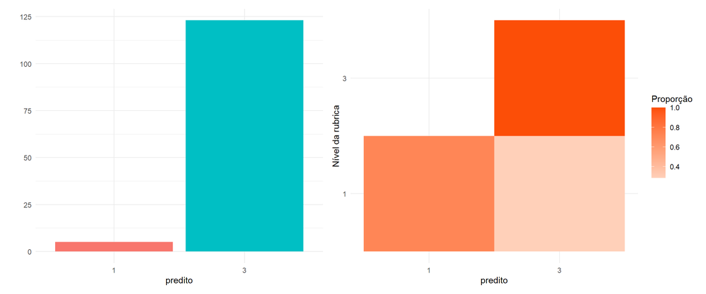

```r
p6$barras + p6$matriz
```

Probabilidades da resposta pertencer a categoria predita nos casos em que houve acerto.

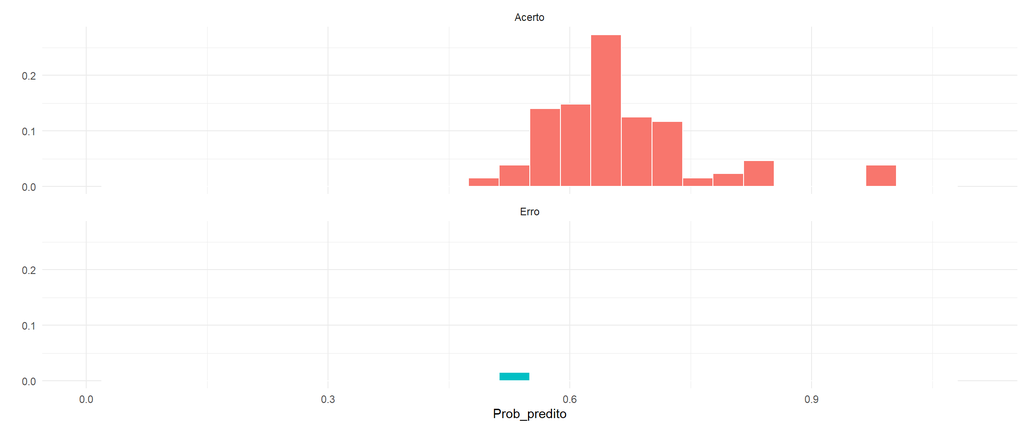

```r
probabilidades_cluster(6, centroides, alunos %>% filter(`Nível da rubrica` != 2)) %>%
  ggplot(aes(x = Prob_predito, y = ..count../sum(..count..), fill = Comp)) +
  geom_histogram(color = "white") +
  facet_wrap(vars(Comp), nrow = 2) +
  xlim(0, 1.1) +
  labs(y = "") + theme(legend.position = "none")
```

## Pergunta 7

```r
p7 <- conglomerado_pergunta(7, centroides, alunos)

# todas_obs7 <- rbind(centroides %>% filter(pergunta_id == 7),
#                     alunos %>% select(-1) %>% filter(pergunta_id == 7))
# n_ouro7 <- nrow(centroides %>% filter(pergunta_id == 7))
# n_teste7 <- nrow(alunos %>% select(-1) %>% filter(pergunta_id == 7))
#
# class7 <-   get_dist(todas_obs7[,3:52]) %>% as.matrix %>%
#   .[(n_ouro7+1):(n_teste7+n_ouro7), 1:n_ouro7] %>% as.data.frame() %>%
#   rename_with(~ paste0("V", .)) %>%
#   mutate(id = alunos %>% filter(pergunta_id == 7) %>% pull(estudante_id)) %>%
#   pivot_longer(cols = starts_with("V"), names_to = "Centroide",
#                values_to = "Valores") %>%
#   group_by(id) %>%
#   filter(Valores == min(Valores)) %>%
#   mutate(predito = str_replace(Centroide, "V", "")) %>%
#   rename(estudante_id = id)
#
# banco7 <- alunos %>% filter(pergunta_id == 7) %>%
#   left_join(class7 %>% select(estudante_id, predito))
#
# barras7 <- banco7 %>%
#   ggplot(aes(predito, fill = predito)) +
#   geom_bar() + labs(y = "") + theme_minimal() +
#   theme(legend.position = "none")
#
# matriz7 <- banco7 %>%
#   group_by(predito, `Nível da rubrica`) %>%
#   count() %>%
#   group_by(`Nível da rubrica`) %>%
#   mutate("Proporção" = n/sum(n)) %>%
#   ggplot(aes(x = predito, y =`Nível da rubrica`, fill = `Proporção`)) +
#   geom_tile() +
#   scale_fill_gradient2(low = "#00AFBB", high = "#FC4E07")
#
# perc_acerto7_n <- banco7 %>%
#   mutate(acerto = (predito == `Nível da rubrica`)) %>%
#   pull(acerto) %>% sum()/n_teste7
# perc_acerto7 <- paste("A proporção de acerto é igual a", round(perc_acerto7_n, 2)*100,"%.")
#
# p7 <- list(barras = barras7,
#            matriz = matriz7,
#            perc_acerto = perc_acerto7,
#            perc_acerto_n = perc_acerto7_n,
#            banco = banco7)
```

| Pergunta | Nível da rubrica | n | Predito |
| --- | --- | --- | --- |
| Como foi feita a escolha do nome Zé Gotinha? | 1 | 20 | 12 |
| Como foi feita a escolha do nome Zé Gotinha? | 2 | 101 | 36 |
| Como foi feita a escolha do nome Zé Gotinha? | 3 | 15 | 74 |

```r
p7$perc_acerto
```

[1] “A proporção de acerto é igual a 46 %.”

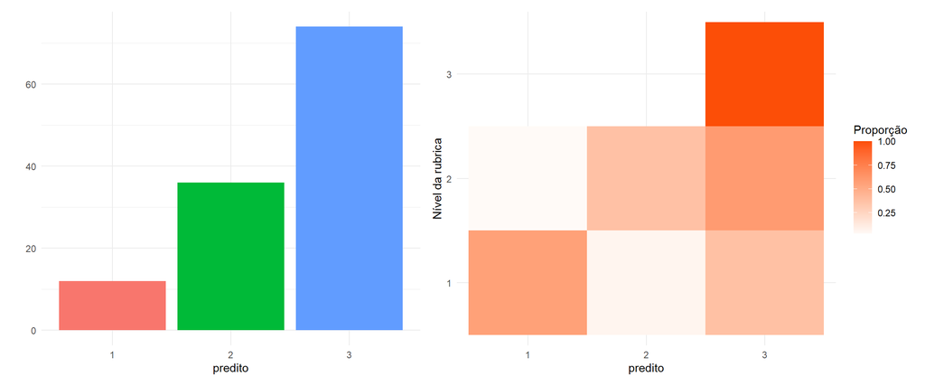

```r
p7$barras + p7$matriz
```

Probabilidades da resposta pertencer a categoria predita nos casos em que houve acerto.

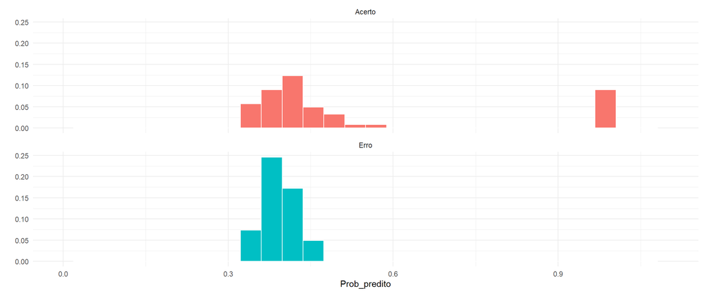

```r
probabilidades_cluster(7, centroides, alunos) %>%
  ggplot(aes(x = Prob_predito, y = ..count../sum(..count..), fill = Comp)) +
  geom_histogram(color = "white") +
  facet_wrap(vars(Comp), nrow = 2) +
  xlim(0, 1.1) +
  labs(y = "") + theme(legend.position = "none")
```

## Pergunta 8

| Pergunta | Nível da rubrica | n | Predito |
| --- | --- | --- | --- |
| Por que os organizadores entenderam que o nome deveria ser Zé Gotinha? | 1 | 49 | 29 |
| Por que os organizadores entenderam que o nome deveria ser Zé Gotinha? | 2 | 32 | 19 |
| Por que os organizadores entenderam que o nome deveria ser Zé Gotinha? | 3 | 55 | 74 |

```r
p8$perc_acerto
```

[1] “A proporção de acerto é igual a 71 %.”

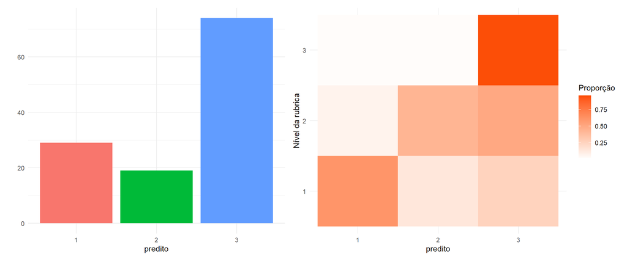

```r
p8$barras + p8$matriz
```

Probabilidades da resposta pertencer a categoria predita nos casos em que houve acerto.

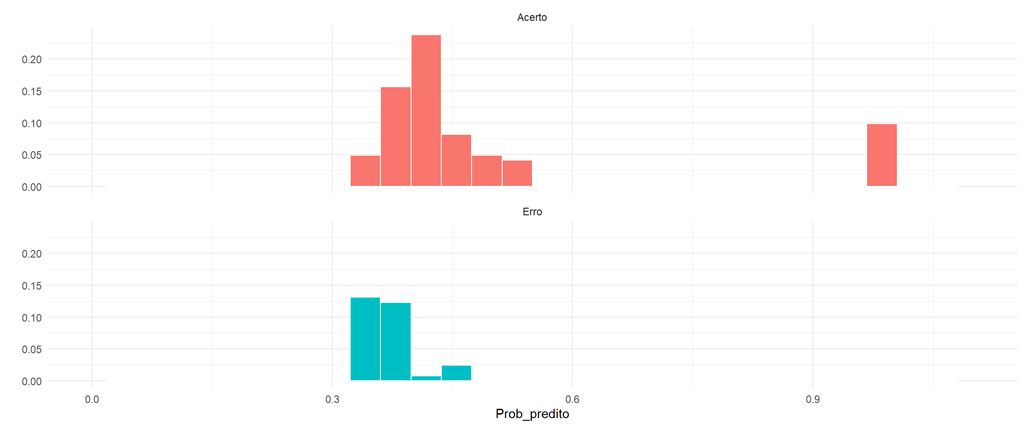

```r
probabilidades_cluster(8, centroides, alunos) %>%
  ggplot(aes(x = Prob_predito, y = ..count../sum(..count..), fill = Comp)) +
  geom_histogram(color = "white") +
  facet_wrap(vars(Comp), nrow = 2) +
  xlim(0, 1.1) +
  labs(y = "") + theme(legend.position = "none")
```

## Pergunta 9

| Pergunta | Nível da rubrica | n | Predito |
| --- | --- | --- | --- |
| Quem levou o prêmio pela escolha do nome? | 1 | 13 | 8 |
| Quem levou o prêmio pela escolha do nome? | 2 | 4 | NA |
| Quem levou o prêmio pela escolha do nome? | 3 | 119 | 118 |

```r
p9$perc_acerto
```

[1] “A proporção de acerto é igual a 98 %.”

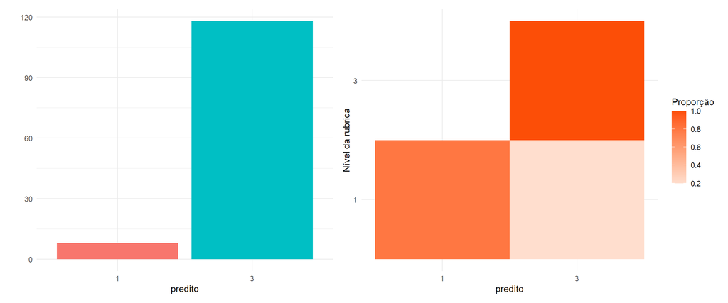

```r
p9$barras + p9$matriz
```

Probabilidades da resposta pertencer a categoria predita nos casos em que houve acerto.

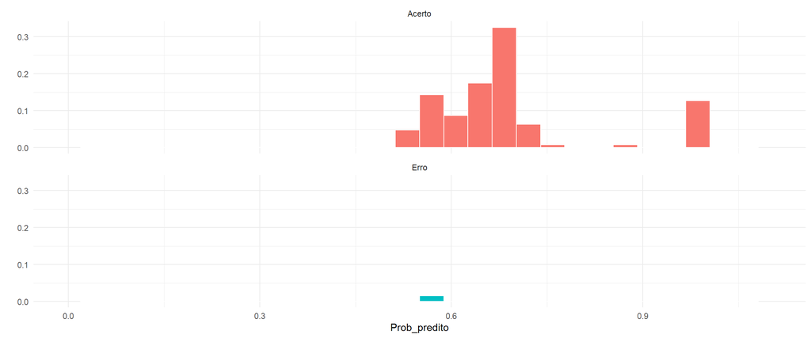

```r
probabilidades_cluster(9, centroides,
                       alunos %>% filter(`Nível da rubrica` != 2)) %>%
  ggplot(aes(x = Prob_predito, y = ..count../sum(..count..), fill = Comp)) +
  geom_histogram(color = "white") +
  facet_wrap(vars(Comp), nrow = 2) +
  xlim(0, 1.1) +
  labs(y = "") + theme(legend.position = "none")
```

## Pergunta 10

| Pergunta | Nível da rubrica | n | Predito |
| --- | --- | --- | --- |
| Qual era a ideia principal da campanha do Zé Gotinha? | 1 | 22 | 3 |
| Qual era a ideia principal da campanha do Zé Gotinha? | 2 | 42 | 32 |
| Qual era a ideia principal da campanha do Zé Gotinha? | 3 | 72 | 92 |

```r
p10$perc_acerto
```

```
## [1] "A proporção de acerto é igual a 54 %."
```

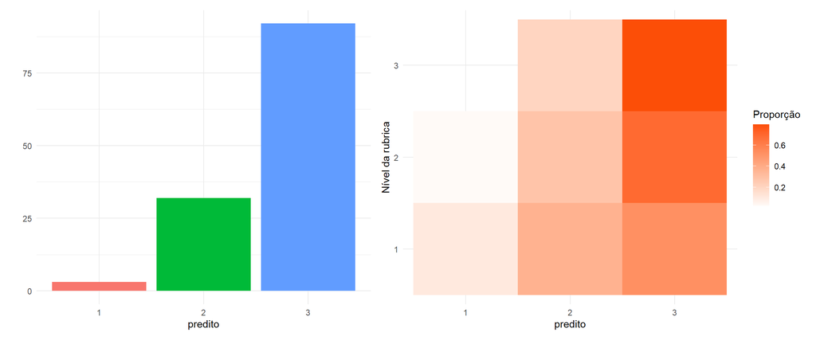

```r
p10$barras + p10$matriz
```

Probabilidades da resposta pertencer a categoria predita nos casos em que houve acerto.

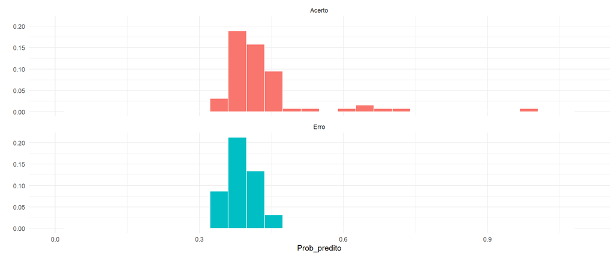

```r
probabilidades_cluster(10, centroides, alunos) %>%
  ggplot(aes(x = Prob_predito, y = ..count../sum(..count..), fill = Comp)) +
  geom_histogram(color = "white") +
  facet_wrap(vars(Comp), nrow = 2) +
  xlim(0, 1.1) +
  labs(y = "") + theme(legend.position = "none")
```

## Pergunta 11

| Pergunta | Nível da rubrica | n | Predito |
| --- | --- | --- | --- |
| Por que vacina é um assunto sério? | 1 | 20 | 13 |
| Por que vacina é um assunto sério? | 2 | 67 | 21 |
| Por que vacina é um assunto sério? | 3 | 49 | 93 |

```r
p11$perc_acerto
```

[1] “A proporção de acerto é igual a 55 %.”

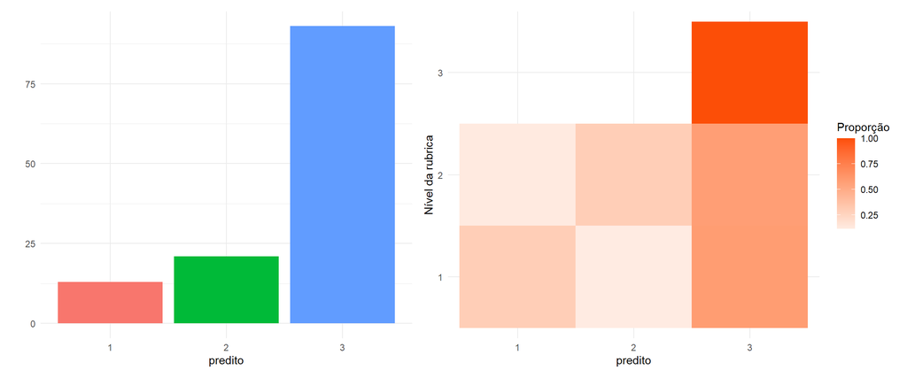

```r
p11$barras + p11$matriz
```

Probabilidades da resposta pertencer a categoria predita nos casos em que houve acerto.

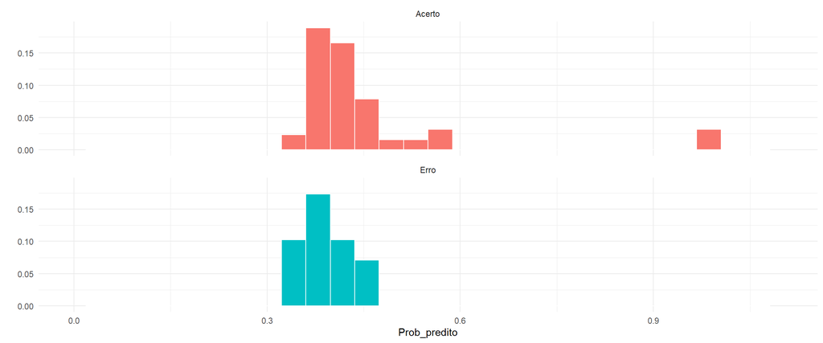

```r
probabilidades_cluster(11, centroides, alunos) %>%
  ggplot(aes(x = Prob_predito, y = ..count../sum(..count..), fill = Comp)) +
  geom_histogram(color = "white") +
  facet_wrap(vars(Comp), nrow = 2) +
  xlim(0, 1.1) +
  labs(y = "") + theme(legend.position = "none")
```

## Pergunta 12

| Pergunta | Nível da rubrica | n | Predito |
| --- | --- | --- | --- |
| Por que não é preciso ter medo de tomar vacina? | 1 | 3 | NA |
| Por que não é preciso ter medo de tomar vacina? | 2 | 64 | 19 |
| Por que não é preciso ter medo de tomar vacina? | 3 | 69 | 106 |

```r
p12$perc_acerto
```

[1] “A proporção de acerto é igual a 62 %.”

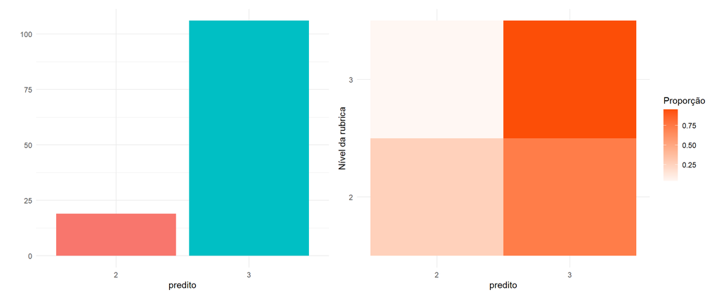

```r
p12$barras + p12$matriz
```

Probabilidades da resposta pertencer a categoria predita nos casos em que houve acerto.

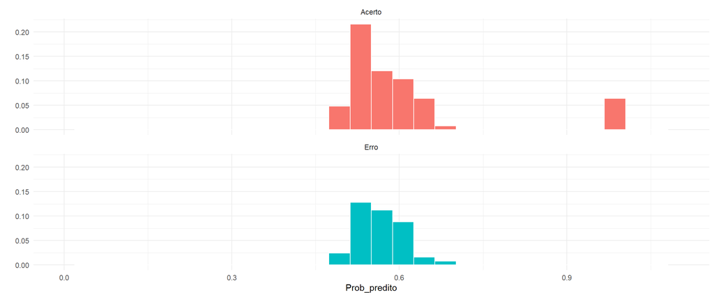

```r
probabilidades_cluster(12, centroides,
                       alunos %>% filter(`Nível da rubrica` != 1)) %>%
  ggplot(aes(x = Prob_predito, y = ..count../sum(..count..), fill = Comp)) +
  geom_histogram(color = "white") +
  facet_wrap(vars(Comp), nrow = 2) +
  xlim(0, 1.1) +
  labs(y = "") + theme(legend.position = "none")
```

## Pergunta 13

| Pergunta | Nível da rubrica | n | Predito |
| --- | --- | --- | --- |
| O que é poliomielite? | 1 | 10 | 2 |
| O que é poliomielite? | 2 | 39 | 19 |
| O que é poliomielite? | 3 | 87 | 103 |

```r
p13$perc_acerto
```

[1] “A proporção de acerto é igual a 81 %.”

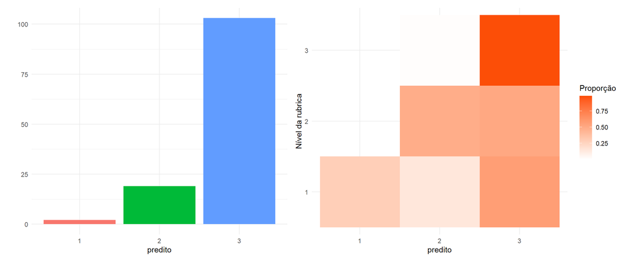

```r
p13$barras + p13$matriz
```

Probabilidades da resposta pertencer a categoria predita nos casos em que houve acerto.

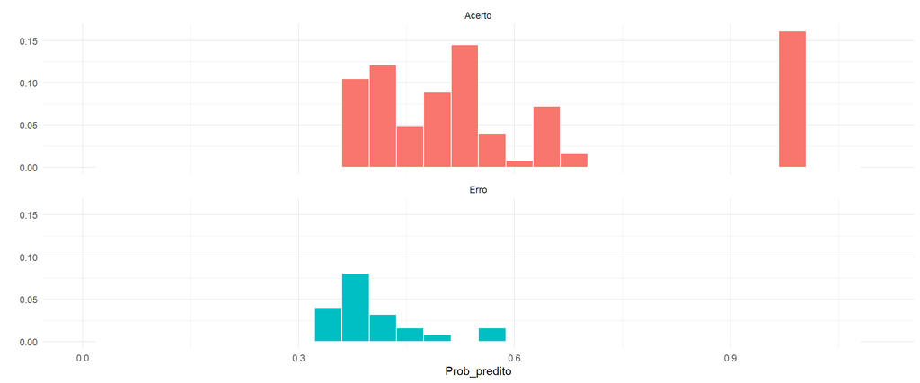

```r
probabilidades_cluster(13, centroides, alunos) %>%
  ggplot(aes(x = Prob_predito, y = ..count../sum(..count..), fill = Comp)) +
  geom_histogram(color = "white") +
  facet_wrap(vars(Comp), nrow = 2) +
  xlim(0, 1.1) +
  labs(y = "") + theme(legend.position = "none")
```

## Pergunta 14

| Pergunta | Nível da rubrica | n | Predito |
| --- | --- | --- | --- |
| Levante hipótese do porquê de o concurso ter sido feito por meio de cartas. | 1 | 44 | 30 |
| Levante hipótese do porquê de o concurso ter sido feito por meio de cartas. | 2 | 73 | 57 |
| Levante hipótese do porquê de o concurso ter sido feito por meio de cartas. | 3 | 19 | 39 |

```r
p14$perc_acerto
```

[1] “A proporção de acerto é igual a 60 %.”

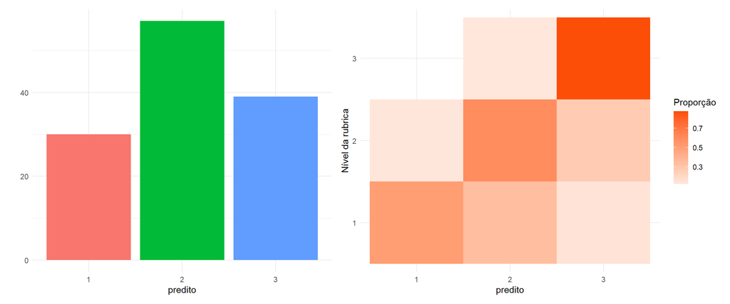

```r
p14$barras + p14$matriz
```

Probabilidades da resposta pertencer a categoria predita nos casos em que houve acerto.

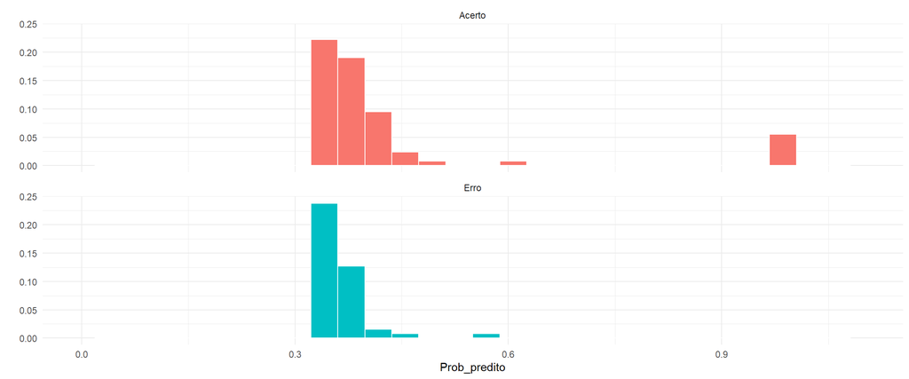

```r
probabilidades_cluster(14, centroides, alunos) %>%
  ggplot(aes(x = Prob_predito, y = ..count../sum(..count..), fill = Comp)) +
  geom_histogram(color = "white") +
  facet_wrap(vars(Comp), nrow = 2) +
  xlim(0, 1.1) +
  labs(y = "") + theme(legend.position = "none")
```

## Pergunta 15

| Pergunta | Nível da rubrica | n | Predito |
| --- | --- | --- | --- |
| O que há no personagem que incentiva as crianças a se vacinarem? | 1 | 53 | 23 |
| O que há no personagem que incentiva as crianças a se vacinarem? | 2 | 62 | 29 |
| O que há no personagem que incentiva as crianças a se vacinarem? | 3 | 21 | 71 |

```r
p15$perc_acerto
```

[1] “A proporção de acerto é igual a 35 %.”

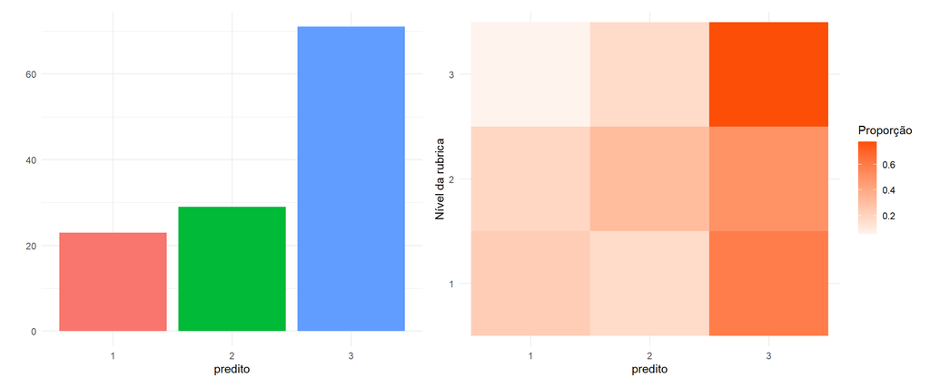

```r
p15$barras + p15$matriz
```

Probabilidades da resposta pertencer a categoria predita nos casos em que houve acerto.

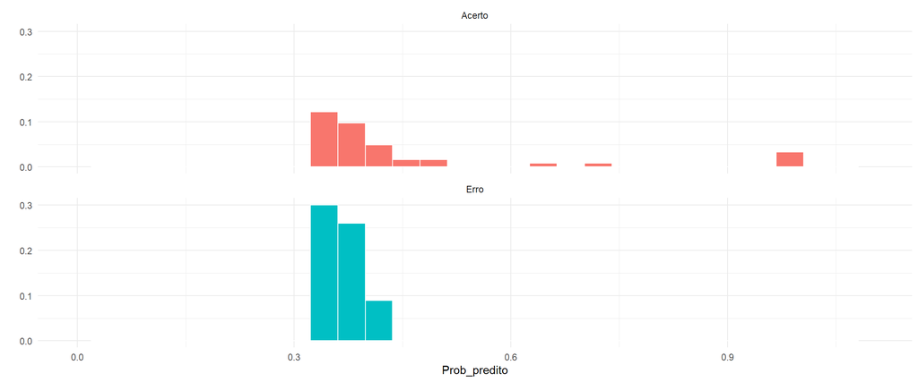

```r
probabilidades_cluster(15, centroides, alunos) %>%
  ggplot(aes(x = Prob_predito, y = ..count../sum(..count..), fill = Comp)) +
  geom_histogram(color = "white") +
  facet_wrap(vars(Comp), nrow = 2) +
  xlim(0, 1.1) +
  labs(y = "") + theme(legend.position = "none")
```

## Pergunta 16

| Pergunta | Nível da rubrica | n | Predito |
| --- | --- | --- | --- |
| O que o criador do Zé Gotinha faz atualmente? | 1 | 23 | 8 |
| O que o criador do Zé Gotinha faz atualmente? | 2 | 1 | NA |
| O que o criador do Zé Gotinha faz atualmente? | 3 | 112 | 115 |

```r
p16$perc_acerto
```

[1] “A proporção de acerto é igual a 86 %.”

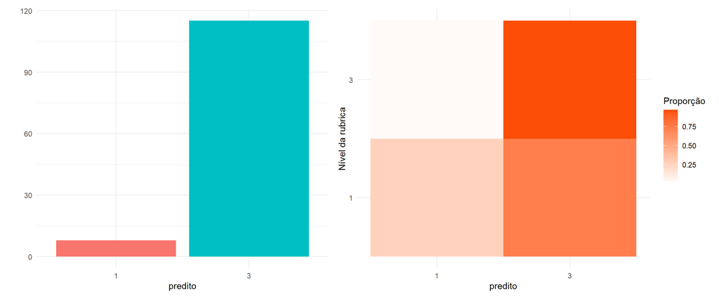

```r
p16$barras + p16$matriz
```

Probabilidades da resposta pertencer a categoria predita nos casos em que houve acerto.

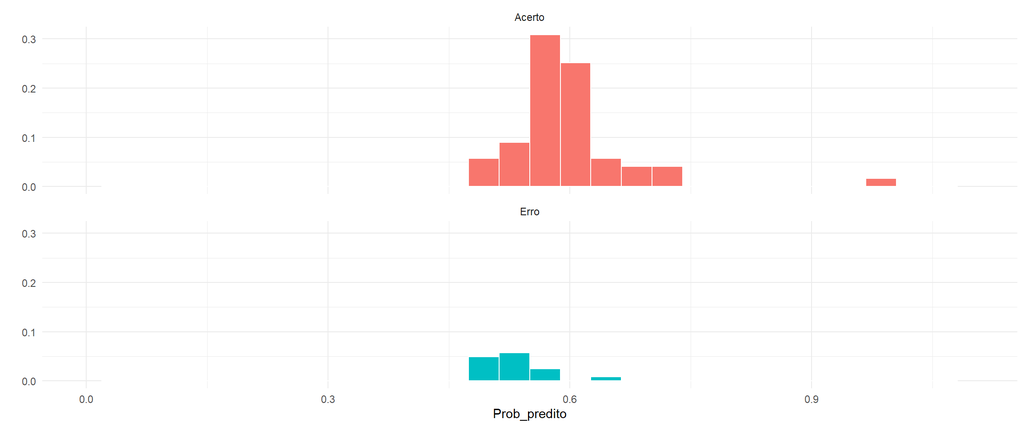

```r
probabilidades_cluster(16, centroides,
                       alunos %>% filter(`Nível da rubrica` != 2)) %>%
  ggplot(aes(x = Prob_predito, y = ..count../sum(..count..), fill = Comp)) +
  geom_histogram(color = "white") +
  facet_wrap(vars(Comp), nrow = 2) +
  xlim(0, 1.1) +
  labs(y = "") + theme(legend.position = "none")
```

## Pergunta 17

| Pergunta | Nível da rubrica | n | Predito |
| --- | --- | --- | --- |
| Você deve ter percebido que há vários trechos, ao longo desta reportagem, que estão entre aspas. Para que serve esse recurso nesse texto? | 1 | 24 | 27 |
| Você deve ter percebido que há vários trechos, ao longo desta reportagem, que estão entre aspas. Para que serve esse recurso nesse texto? | 2 | 102 | 56 |
| Você deve ter percebido que há vários trechos, ao longo desta reportagem, que estão entre aspas. Para que serve esse recurso nesse texto? | 3 | 10 | 42 |

```r
p17$perc_acerto
```

[1] “A proporção de acerto é igual a 50 %.”

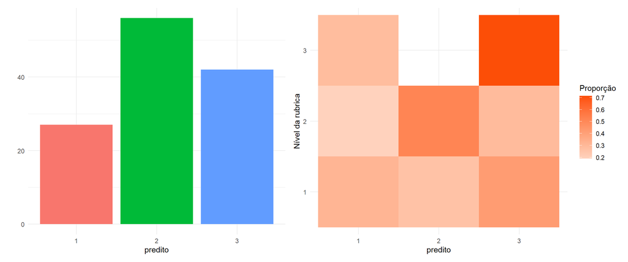

```r
p17$barras + p17$matriz
```

Probabilidades da resposta pertencer a categoria predita nos casos em que houve acerto.

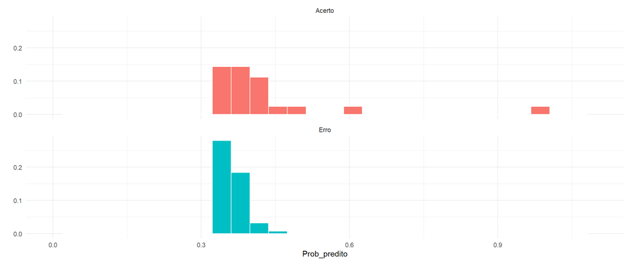

```r
probabilidades_cluster(17, centroides, alunos) %>%
  ggplot(aes(x = Prob_predito, y = ..count../sum(..count..), fill = Comp)) +
  geom_histogram(color = "white") +
  facet_wrap(vars(Comp), nrow = 2) +
  xlim(0, 1.1) +
  labs(y = "") + theme(legend.position = "none")
```

## Pergunta 18

| Pergunta | Nível da rubrica | n | Predito |
| --- | --- | --- | --- |
| No seguinte fragmento há um fato e uma opinião. Sublinhe o fato e circule a opinião. Darlan virou até nome de prédio residencial na cidade. “Aqui, sou uma pessoa ilustre”, brinca. | 1 | 39 | 41 |
| No seguinte fragmento há um fato e uma opinião. Sublinhe o fato e circule a opinião. Darlan virou até nome de prédio residencial na cidade. “Aqui, sou uma pessoa ilustre”, brinca. | 2 | 14 | 10 |
| No seguinte fragmento há um fato e uma opinião. Sublinhe o fato e circule a opinião. Darlan virou até nome de prédio residencial na cidade. “Aqui, sou uma pessoa ilustre”, brinca. | 3 | 83 | 87 |

```r
p18$perc_acerto
```

[output not shown]

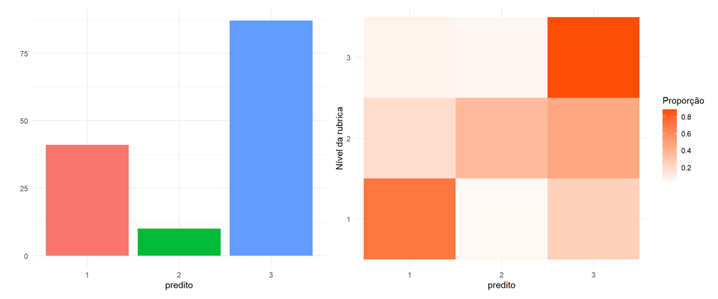

```r
p18$barras + p18$matriz
```

Probabilidades da resposta pertencer a categoria predita nos casos em que houve acerto. ESSE DÁ ERROO

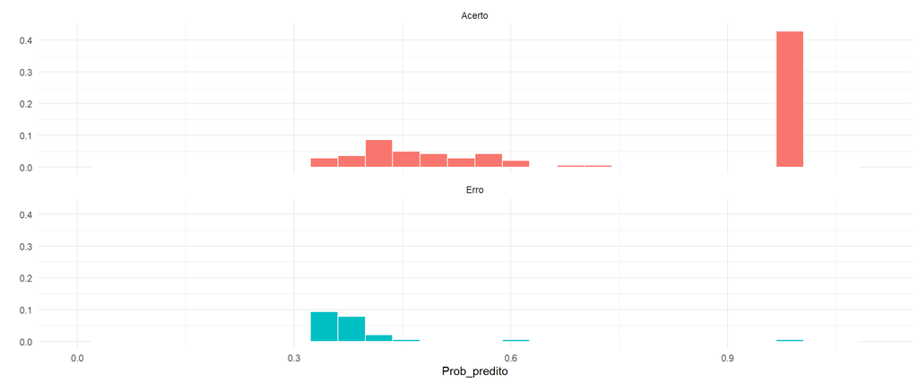

```r
probabilidades_cluster(18, centroides, alunos) %>%
  ggplot(aes(x = Prob_predito, y = ..count../sum(..count..), fill = Comp)) +
  geom_histogram(color = "white") +
  facet_wrap(vars(Comp), nrow = 2) +
  xlim(0, 1.1) +
  labs(y = "") + theme(legend.position = "none")
```

## Pergunta 19

| Pergunta | Nível da rubrica | n | Predito |
| --- | --- | --- | --- |
| Releia o seguinte trecho: “As crianças começaram a querer ir ao posto de vacinação. A barreira dos medos acabou, e a campanha deslanchou. O Zé Gotinha é um orgulho na minha vida, ele deu muito certo.”… | 1 | 19 | 8 |
| Releia o seguinte trecho: “As crianças começaram a querer ir ao posto de vacinação. A barreira dos medos acabou, e a campanha deslanchou. O Zé Gotinha é um orgulho na minha vida, ele deu muito certo.”… | 2 | 64 | 31 |
| Releia o seguinte trecho: “As crianças começaram a querer ir ao posto de vacinação. A barreira dos medos acabou, e a campanha deslanchou. O Zé Gotinha é um orgulho na minha vida, ele deu muito certo.”… | 3 | 53 | 84 |

```r
p19$perc_acerto
```

[1] “A proporção de acerto é igual a 31 %.”

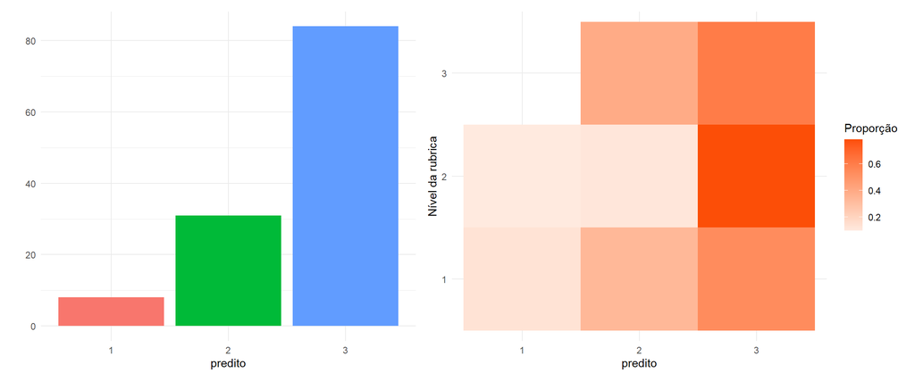

```r
p19$barras + p19$matriz
```

Probabilidades da resposta pertencer a categoria predita nos casos em que houve acerto.

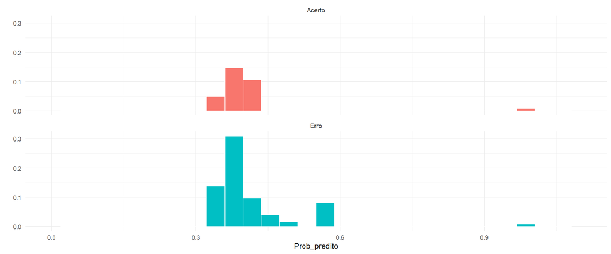

```r
probabilidades_cluster(19, centroides, alunos) %>%
  ggplot(aes(x = Prob_predito, y = ..count../sum(..count..), fill = Comp)) +
  geom_histogram(color = "white") +
  facet_wrap(vars(Comp), nrow = 2) +
  xlim(0,1.1) +
  labs(y = "") + theme(legend.position = "none")
```

## Pergunta 20

| Pergunta | Nível da rubrica | n | Predito |
| --- | --- | --- | --- |
| Há expressões que são usadas com outros sentidos. Veja o trecho em destaque. “Os adultos podem até não confessar, mas com certeza já choraram para tomar injeção na hora da vacina alguma vez na vida. E… | 1 | 36 | 15 |
| Há expressões que são usadas com outros sentidos. Veja o trecho em destaque. “Os adultos podem até não confessar, mas com certeza já choraram para tomar injeção na hora da vacina alguma vez na vida. E… | 2 | 6 | 10 |
| Há expressões que são usadas com outros sentidos. Veja o trecho em destaque. “Os adultos podem até não confessar, mas com certeza já choraram para tomar injeção na hora da vacina alguma vez na vida. E… | 3 | 94 | 96 |

```r
p20$perc_acerto
```

[1] “A proporção de acerto é igual a 72 %.”

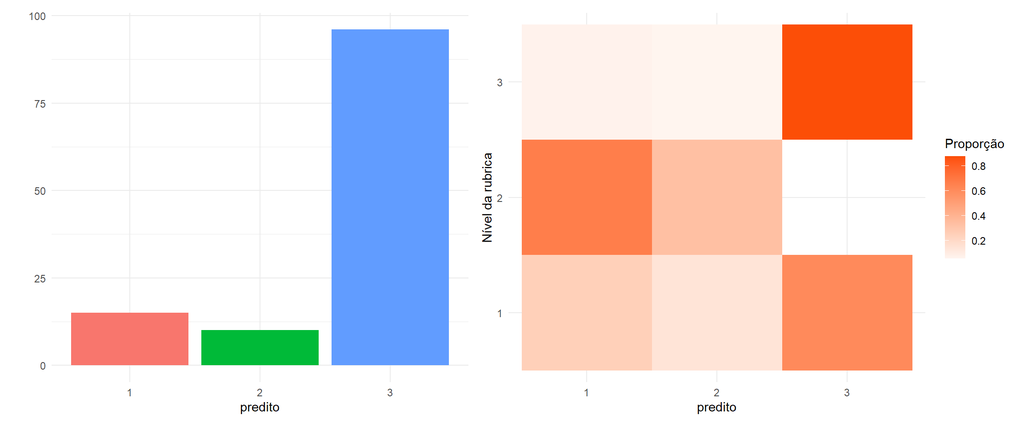

```r
p20$barras + p20$matriz
```

Probabilidades da resposta pertencer a categoria predita nos casos em que houve acerto.

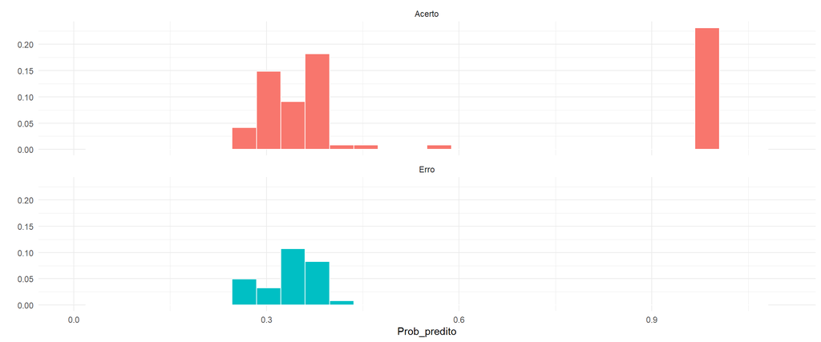

```r
probabilidades_cluster(20, centroides, alunos) %>%
  ggplot(aes(x = Prob_predito, y = ..count../sum(..count..), fill = Comp)) +
  geom_histogram(color = "white") +
  facet_wrap(vars(Comp), nrow = 2) +
  xlim(0, 1.1) +
  labs(y = "") + theme(legend.position = "none")
```